# Story House Sale Prices: eXplainable predictions for house sale

*Authors: Piotr Grązka (SGH Warsaw School of Economics), Anna Kozak (Warsaw University of Technology), Paweł Wicherek (Warsaw University of Technology)*

*Mentors: Mateusz Zawisza (McKinsey & Company), Adam Zmaczyński (McKinsey & Company)*

> ‘’That’s all your house is: it’s a place to keep your stuff while you go out and get more stuff.’’

## Introduction

Everybody needs a roof over their heads. It can be a house, villa, or a flat. Everybody, at some point in life, faces a choice if to buy a house. If so, which one. And why they are so expensive?

The topic of real estate is not only the topic you just have to deal with. It can also be very interesting. There are plenty of TV Shows, for instance, *Property Brothers*, of which plot is based on examples of people buying and renovating houses. This particular one is the most famous in the world and has been running already for almost a decade. For many people houses are also products to buy and sell with income.

Regardless of motives of buy/sell real estate, both sides agree to a price. It is always good to know, **how much** it is worth, what’s the fair/true value. And, maybe it’s even more important, **why** the price is like that, what has an influence on it.

In this work we want to try to find an answer to both questions with a stronger emphasis on the second one. This paper is intended to be a complete use case on how to deal with the regression problem for Data Scientists. Let’s start with a couple of questions that will allow us to understand and define the problems

- *The seller does not know how to increase the cost of the apartment so that the investment outlay is lower than the added value (e.g. building a pool will increase the price and renovating the bathroom is not worth it).*
- *The seller does not know how much to sell the apartment for (he makes an offer on the portal and does not know if the price is fair).*
- *The buyer does not know how much the apartment is worth (as above, whether the price is fair).*
- *Commercial problem: Auction services do not have tools to support sellers/buyers.*

These are just some of the questions we can ask. As a definition of our problem, we have set ourselves a property valuation, and thorough explanations we will try to get an answer depending on the position we choose.

We have divided our work into several stages, below we present a diagram (Figure @ref(fig:plan)) with a step plan. It allowed us to plan our work, and now we will use it to tell you what we did.

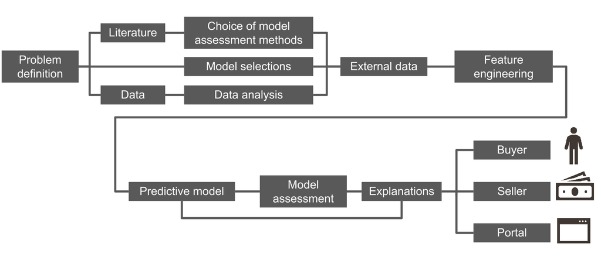

A scheme with a step-by-step plan that allowed us to plan our work.

We started our work with a literature review. Many papers show a comparison of hedonistic models (linear regression) and machine learning models. Below is a graph with results achieved by models that can be interpreted by design (hedonistic) and black box model (ANN) based on the article [@house_prices].

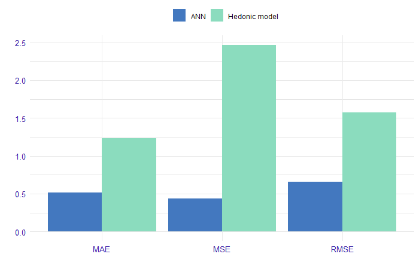

Comparison of the performance of hedonic regression model and ANN(artificial neural networks).

We can conclude from Figure @ref(fig:paper-plot) that we reduce the interpretability to an increase in the quality of model fitting.

The next point was data analysis, we work on a dataset which contains house sale prices for King County, which includes Seattle. It is include homes sold between May 2014 and May 2015. Data available on [kaggle](https://www.kaggle.com/harlfoxem/housesalesprediction) and [openml](https://www.openml.org/d/42079). We have analyzed the data, [more](https://github.com/kozaka93/InterpretableHouseSalePrices/tree/master/Data/DataAnalysis). Data contains 19 house features plus the price and the id columns, along with 21613 observations.

Description of variables in the dataset.

| Variable | Description |
| --- | --- |
| `id` | unique ID for each home sold |
| `date` | date of the home sale |
| `price` | price of each home sold |
| `bedrooms` | number of bedrooms |
| `bathrooms` | number of bathrooms, where .5 accounts for a room with a toilet but no shower |
| `sqft_living` | square footage of the apartments interior living space |
| `sqft_lot` | square footage of the land space |
| `floors` | number of floors |
| `waterfront` | apartment was overlooking the waterfront or not |
| `view` | how good the view of the property was |
| `condition` | condition of the apartment |
| `grade` | level of construction and design |
| `sqft_above` | the square footage of the interior housing space that is above ground level |
| `sqft_basement` | the square footage of the interior housing space that is below ground level |
| `yr_built` | the year the house was initially built |
| `yr_renovated` | the year of the house’s last renovation |
| `zipcode` | zipcode area |
| `lat` | lattitude |
| `long` | longitude |
| `sqft_living15` | the square footage of interior housing living space for the nearest 15 neighbors |
| `sqft_lot15` | the square footage of the land lots of the nearest 15 neighbors |

We have collected methods to evaluate the performance of the regression model, we decided to use RMSE (root mean square errors).

Based on the literature we decided to test the following models:

- fixed effects model
- random effects model
- Spatial Autoregressive (SAR) model
- linear regression
- decision tree
- random forest
- gradient boosting, xgboost

Another idea of how to enrich our solution was to add external data. The location of the property can significantly affect the price, so we also took into account the distance from public transport and the number of cultural facilities within a kilometer radius.

## Data preperation

[Original data from kaggle](https://www.kaggle.com/harlfoxem/housesalesprediction) is in good quality at the start, but we need to preprocess it to suit our needs. In this section we want to describe how we prepared ready-to-use `csv`s of the train and test data ([`train.csv`](https://github.com/kozaka93/InterpretableHouseSalePrices/blob/master/Data/TrainAndTest/test.csv), [`test.csv`](https://github.com/kozaka93/InterpretableHouseSalePrices/blob/master/Data/TrainAndTest/train.csv). This includes variable transformations, joining external data, records processing.

Firstly, we discovered that there are houses that were sold twice, and one house that was sold three times. One can assume, that it was bought, renovated and then sold for more. But they have the same explanatory variables, no changes. Each pair (triple) of houses we decide to aggregate into a single row with averaging the price.

Secondly, we decided to add external data. Why? We believe most variables describe the house properly. What we are missing is some spatial information. Except zip code, we have longitude and latitude – good, that’d be helpful – but we want to explain it more. Why some locations tend to be more expensive? Maybe it’s because of public transport availability. That’s why we decided to add a variable describing a distance to the nearest bus/subway stop. Data source can be found [here](https://www.kingcounty.gov/depts/transportation/metro/travel-options/bus/app-center/developer-resources.aspx).

There might be also another reason. Maybe some houses are more expensive, because of some interesting places around, like museums, galleries or fine restaurants. We’ll call them *cultural places*. Those places are not only standalone facilities, but they are connected to other infrastructure, which generally should increase the price. This time we decided to look in the neighborhood: we search for a number of such places in arbitrarily chosen 1km range. Data obtained from [here](https://data.seattle.gov/Community/Seattle-Cultural-Space-Inventory/vsxr-aydq).

We also did several variable transformations. Since for authors it is hard to think in square feet, we translate it into square meters. `zipcode` and `waterfront` are saved as factors. Further, for us it’s easier for us to interpret the age of a building rather than a year when it was built. We also know, if and when a house has been renovated. We can also analyze *relative age*, that is the time which has past since last renovation (variable `since_renovated`). Here we also log the price, since we want to work on a relative scale.

The last step is division the data into train and test samples randomly with ratio 70/30.

Ready script for processing the original data from kaggle is on the github. For spatial data analysis, we were using a short script [`geofast`](https://github.com/kozaka93/InterpretableHouseSalePrices/blob/master/Data/TrainAndTest/geofast.py). Distances between two arbitrary points on earth can be obtained from the [@geopy] package for Python. However, general and precise formula is computationally expensive. With a simple trick, it can be adjusted to our case without losing almost any precision. This can be done by providing distances to measure are not exceeding several hundred kilometers. The original idea was published [here](https://blog.mapbox.com/fast-geodesic-approximations-with-cheap-ruler-106f229ad016).

## Model

Our main goal, as we mentioned before, is to explain the model of choice. Along self-explanatory linear models included as comparison, we considered models including:

- decision tree
- random forest
- gradient boosting
- xgboost.

As mentioned earlier, the variables `zipcode` and `waterfront` were introduced as categorical. These models were built. Additionally, for the `zipcode` variable, which has 70 levels, we use one-hot encoding and build models again. The models are built in `mlr` [@mlr] R package with `ranger` [@ranger], `gbm` [@gbm], `xgboost` [@XGBoost] and `rpart` [@rpart].

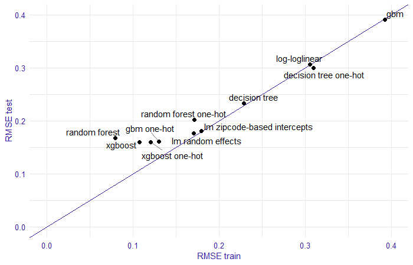

Comparison of model performance by RMSE on training and test set. In the plot the trained models are marked with points, on the x-axis we have RMSE measure for the training set, on the y-axis the RMSE score for the test set, the line stands for RMSE equal on training and test sets

Model results on the training and test set.

| Model | RMSE train | RMSE test |
| --- | --- | --- |
| random forest | 0.07931109 | 0.1674559 |
| xgboost | 0.1076962 | 0.1600113 |

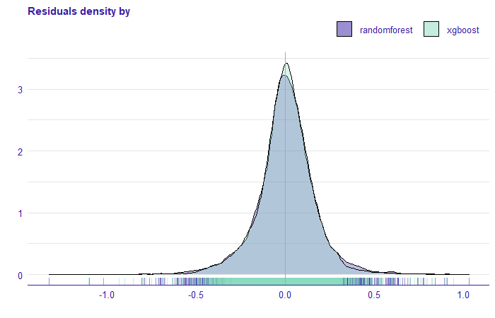

Residuals density for random forest and xgboost models.

Comparing the xgboost model with one-hot encoding and gbm with one-hot encoding we see that the RMSE score on the training and test set is very similar. Furthermore, the residual density plot (Figure @ref(fig:residual-2) ) is practically identical.

Model results on the training and test set with one-hot encoding.

| Model | RMSE train | RMSE test |
| --- | --- | --- |
| xgboost one-hot | 0.1207626 | 0.1595913 |
| gbm one-hot | 0.1302585 | 0.1607376 |

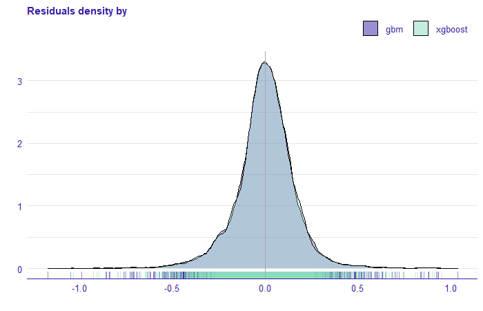

Residuals density for gbm and xgboost models.